# ALS_Dream_Challenge: ALSFRS Slope Prediction

#### **II.Tree-Based Method: Random Forests**

The first algorithm we trained and validated is Random Forests from the randomforests library. By definition, Random Forests is an ensemble of decision trees and incorporates randomness via bootstrapping. The beauty about this model is that it is not prone to overfitting and it can be used for both categorization and regression.

**A. Cluster 1**

*Train Random Forests Model*

```r
#for reproducibility
set.seed(30495)
#traincontrol hyperparameter
oob = trainControl(method = "oob")
#tuneGrid hyperparameter
rf_grid =  expand.grid(mtry = 1:10)
#tuning the random forests model
RF_slope_clus1_ <- train(ALSFRS_Slope ~ . -subject_id, data=training_set_clus1, method="rf", trControl=oob, tuneGrid=rf_grid, importance = TRUE, oob.times = 15, confusion = TRUE)
#best mtry parameter is 1
RF_slope_clus1_$bestTune
```

```
##   mtry
## 3    3
```

```r
#rerun random forests with mtry=1
RF_slope_clus1 <- randomForest(ALSFRS_Slope ~ . -subject_id, data=training_set_clus1, trControl=oob, tuneGrid=rf_grid, mtry=3, importance = TRUE, oob.times = 15, confusion = TRUE)
#best mtry parameter is 1
RF_slope_clus1
```

```
##
## Call:
##  randomForest(formula = ALSFRS_Slope ~ . - subject_id, data = training_set_clus1,      trControl = oob, tuneGrid = rf_grid, mtry = 3, importance = TRUE,      oob.times = 15, confusion = TRUE)
##                Type of random forest: regression
##                      Number of trees: 500
## No. of variables tried at each split: 3
##
##           Mean of squared residuals: 0.001451404
##                     % Var explained: 13.99
```

*Apply Random Forest Model to Test Set and Evaluate via RMSE, MSE, and MAE*

```r
test_RF_slope_clus1 <- predict (RF_slope_clus1 , newdata =test_set_clus1)
```

```r
#RMSE
rf_rmse_clus1 <- rmse(test_set_clus1$ALSFRS_Slope, test_RF_slope_clus1)
rf_rmse_clus1
```

```
## [1] 0.04180745
```

```r
#MSE
rf_mse_clus1 <- mse(test_set_clus1$ALSFRS_Slope, test_RF_slope_clus1)
rf_mse_clus1
```

```
## [1] 0.001747863
```

```r
#MAE
rf_mae_clus1 <- mean(abs(test_RF_slope_clus1-test_set_clus1$ALSFRS_Slope))
rf_mae_clus1
```

```
## [1] 0.03301306
```

**B. Cluster 2**

*Create Random Forests Model*

```r
#for reproducibility
set.seed(30495)
#train the random forests model using the tuneGrid and trainControl defined in the previous chunk
RF_slope_clus2_ <- train(ALSFRS_Slope ~ . -subject_id, data=training_set_clus2, method="rf", tuneGrid=rf_grid, trControl=oob, importance = TRUE, oob.times = 15, confusion = TRUE)
#mtry=3 is the best
RF_slope_clus2_$bestTune
```

```
##   mtry
## 1    1
```

```r
#rerun random forests model with mtry=3
RF_slope_clus2 <- randomForest(ALSFRS_Slope ~ . -subject_id, data=training_set_clus2, tuneGrid=rf_grid, trControl=oob, importance = TRUE, oob.times = 15, confusion = TRUE, mtry=1)
RF_slope_clus2
```

```
##
## Call:
##  randomForest(formula = ALSFRS_Slope ~ . - subject_id, data = training_set_clus2,      tuneGrid = rf_grid, trControl = oob, importance = TRUE, oob.times = 15,      confusion = TRUE, mtry = 1)
##                Type of random forest: regression
##                      Number of trees: 500
## No. of variables tried at each split: 1
##
##           Mean of squared residuals: 0.007144614
##                     % Var explained: -1.1
```

*Apply Random Forest Model to Test Set and Evaluate via RMSE, MSE, and MAE*

```r
test_RF_slope_clus2 <- predict (RF_slope_clus2 , newdata =test_set_clus2)
```

```r
#RMSE
rf_rmse_clus2 <- rmse(test_set_clus2$ALSFRS_Slope, test_RF_slope_clus2)
rf_rmse_clus2
```

```
## [1] 0.07056459
```

```r
#MSE
rf_mse_clus2 <- mse(test_set_clus2$ALSFRS_Slope, test_RF_slope_clus2)
rf_mse_clus2
```

```
## [1] 0.004979362
```

```r
#MAE
rf_mae_clus2 <- mean(abs(test_RF_slope_clus2-test_set_clus2$ALSFRS_Slope))
rf_mae_clus2
```

```
## [1] 0.04103804
```

#### **III.Tree-Based Method: Gradient Boosting Machine (GBM)**

Another tree-based model we implemented is the Gradient Boosting Machine (from the gbm library), which is also a collection of trees. But note that the trees are grown sequentially.

The main hyperparameters that we wanted to tune are the following:

1. interaction.depth: number of splits for each tree
2. n.trees: total number of trees to be incorporated into the model
3. shrinkage: sets the learning rate
4. n.minobsinnode: minimum number of samples in a node of a tree

To determine the exact values for these hyperparameters, we set the tune grid hyperparameter into a grid with an interaction.depth from 1 to 5, n.trees from 1 to 6 multiplied by 500, shrinkage of 0.001, 0.01, or 0.1, and n.minobsinnode of 10. In addition, we set the trainControl hyperparameter to 5-fold cross validation. Once we determined the exact values for the abovementioned hyperparameters, we reran the gbm models and ultimately tested their predictive performance on our validation/testing set.

**A. Cluster 1**

*Train Gradient Boosting Machine*

```r
#use this grid for tuneGrid
gbm_grid =  expand.grid(interaction.depth = 1:5,
                        n.trees = (1:6) * 500,
                        shrinkage = c(0.001, 0.01, 0.1),
                        n.minobsinnode = 10)
#perform cross validation for trainControl hyperparameter
cv_5 = trainControl(method = "cv", number = 5)
#for reproducibility
set.seed(30495)
# train the model
gbm_clus1_<-train(ALSFRS_Slope ~ . -subject_id, data = training_set_clus1 , method = 'gbm', trControl=cv_5, tuneGrid=gbm_grid, verbose = F)
#optimal values for interaction.depth, n.trees, shrinkage, and n.minobsinnode
gbm_clus1_$bestTune
```

```
##    n.trees interaction.depth shrinkage n.minobsinnode
## 26    1000                 5     0.001             10
```

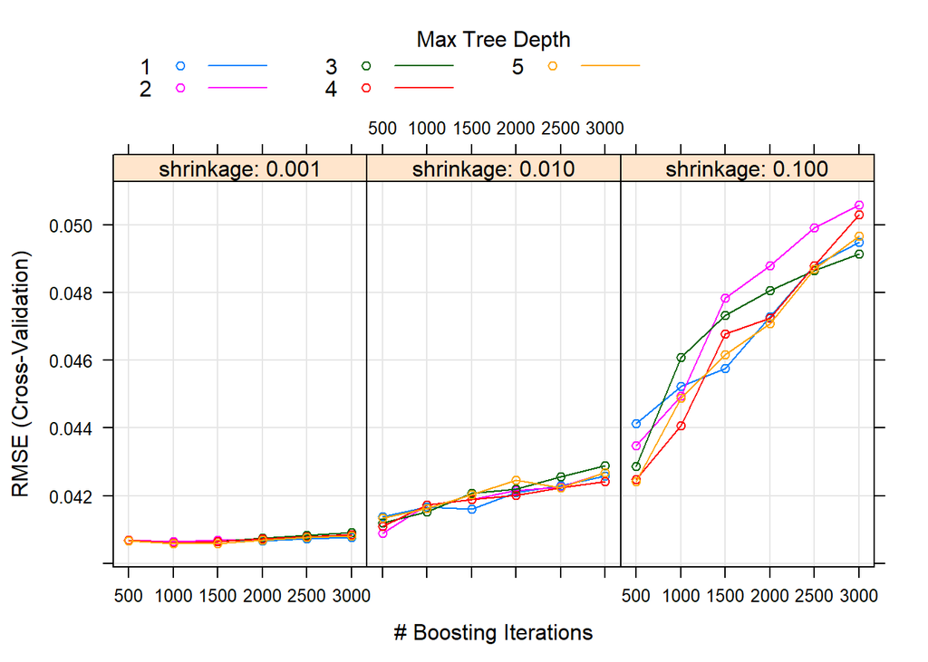

```r
plot(gbm_clus1_)
```

```r
#rerun the algorithm with the optimal hyperparameters
gbm_clus1<-gbm(formula=ALSFRS_Slope ~ . -subject_id, data = training_set_clus1, n.trees=1000, interaction.depth=5, shrinkage=0.001, n.minobsinnode=10,verbose = F)
```

```
## Distribution not specified, assuming gaussian ...
```

*Apply Gradient Boosting Method to Test Set and Evaluate via RMSE, MSE, and MAE*

```r
#apply gbm model to test set
test_gbm_slope_clus1 <- predict (gbm_clus1, n.trees = gbm_clus1$n.trees, test_set_clus1)

#RMSE
gbm_rmse_clus1 <- rmse(test_set_clus1$ALSFRS_Slope, test_gbm_slope_clus1)
gbm_rmse_clus1
```

```
## [1] 0.04207325
```

```r
#MSE
gbm_mse_clus1 <- mse(test_set_clus1$ALSFRS_Slope, test_gbm_slope_clus1)
gbm_mse_clus1
```

```
## [1] 0.001770158
```

```r
#MAE
gbm_mae_clus1 <- mean(abs(test_gbm_slope_clus1-test_set_clus1$ALSFRS_Slope))
gbm_mae_clus1
```

```
## [1] 0.03342604
```

**B. Cluster 2**

*Create Gradient Boosting Method Model*

```r
set.seed(30495)
#use the tuneGrid and trainControl settings defined above to determine the optimal hyperparameters for interaction.depth, shrinkage, n.trees, n.minobsinnode
gbm_clus2_ <-train(ALSFRS_Slope ~ . -subject_id, data = training_set_clus2 , method = 'gbm',trControl=cv_5, tuneGrid=gbm_grid, verbose = F)
gbm_clus2_$bestTune
```

```
##   n.trees interaction.depth shrinkage n.minobsinnode
## 6    3000                 1     0.001             10
```

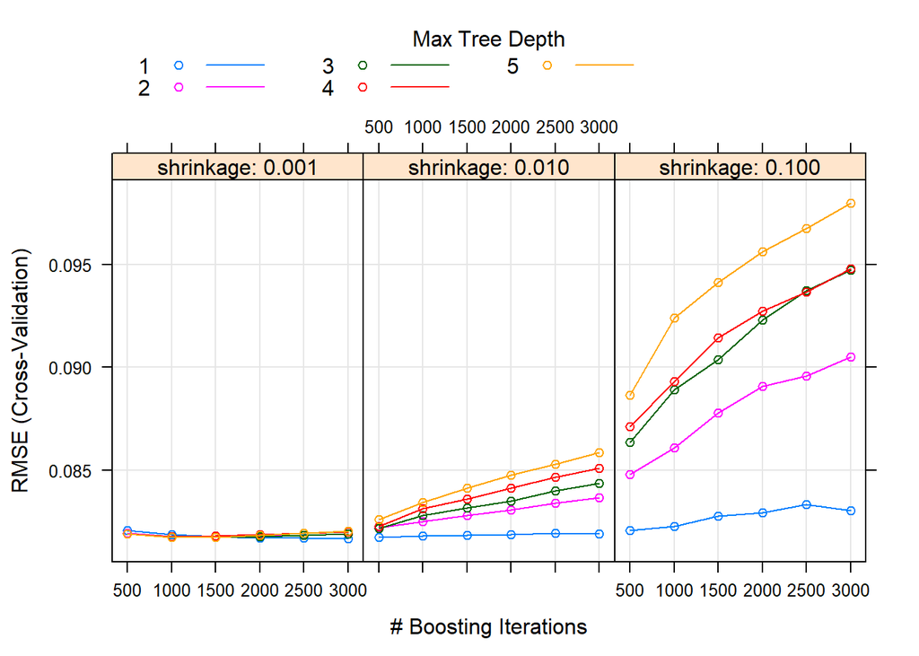

```r
plot(gbm_clus2_)
```

```r
#rerun the gbm model with the optimal hyperparameters
gbm_clus2 <- gbm(formula=ALSFRS_Slope ~ . -subject_id, data = training_set_clus2, n.trees=3000, interaction.depth=1, shrinkage=0.001, n.minobsinnode=10, verbose = F)
```

```
## Distribution not specified, assuming gaussian ...
```

```r
gbm_clus2
```

```
## gbm(formula = ALSFRS_Slope ~ . - subject_id, data = training_set_clus2,
##     n.trees = 3000, interaction.depth = 1, n.minobsinnode = 10,
##     shrinkage = 0.001, verbose = F)
## A gradient boosted model with gaussian loss function.
## 3000 iterations were performed.
## There were 6 predictors of which 6 had non-zero influence.
```

*Apply Gradient Boosting Method to Test Set and Evaluate via RMSE, MSE, and MAE*

```r
#apply gbm model on test set
test_gbm_slope_clus2 <- predict(gbm_clus2, n.trees = gbm_clus2$n.trees, test_set_clus2)

#RMSE
gbm_rmse_clus2 <- rmse(test_set_clus2$ALSFRS_Slope, test_gbm_slope_clus2)
gbm_rmse_clus2
```

```
## [1] 0.06967628
```

```r
#MSE
gbm_mse_clus2 <- mse(test_set_clus2$ALSFRS_Slope, test_gbm_slope_clus2)
gbm_mse_clus2
```

```
## [1] 0.004854784
```

```r
#MAE
gbm_mae_clus2 <- mean(abs(test_gbm_slope_clus2-test_set_clus2$ALSFRS_Slope))
gbm_mae_clus2
```

```
## [1] 0.04104213
```

#### **IV.Regression Shrinkage Method: Lasso Regression**

The third model that we used is the least absolute shrinkage and selection operator (LASSO) regression from the glmnet library. As the its name partially gives it away, lasso regression’s main goal is to select variables that minimizes the prediction error. To be specific, a shrinkage process is performed; variables that have a zero coefficient after shrinkage are eliminated and variables with non-zero coefficient after shrinkage are retained and thus considered important for prediction.

**Cluster 1**

*Train Lasso Regression*

```r
# Custom Control Parameters
custom <- trainControl(method = "repeatedcv", number=10, repeats = 5, verboseIter = F)
#train lasso regression model
set.seed(1234)
lasso_clus1 <- train(ALSFRS_Slope ~ .-subject_id,data=training_set_clus1, method="glmnet", tuneGrid=expand.grid(alpha=1,lambda=seq(0.0001,0.2,length=5)), trControl=custom )
```

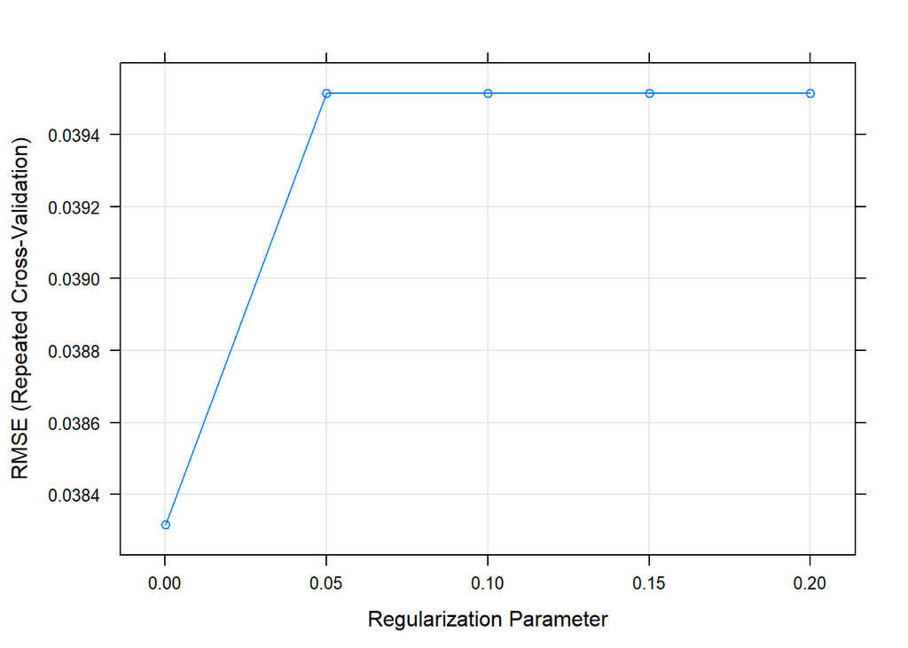

```r
par(mfrow=c(1,2))
a <- plot(lasso_clus1)
a
```

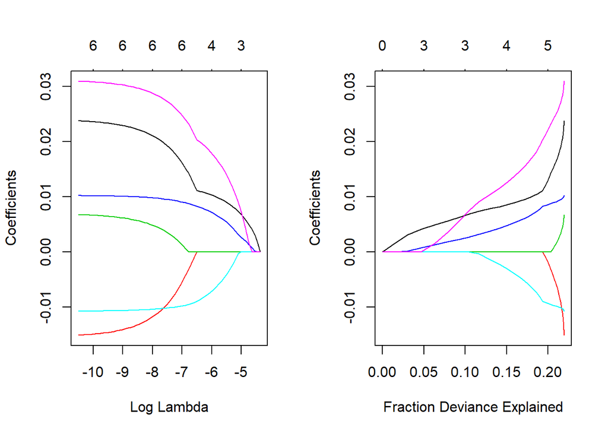

```r
b <- plot(lasso_clus1$finalModel,xvar="lambda", label=T)
c <- plot(lasso_clus1$finalModel,xvar="dev",label=T)
```

*Apply Lasso Regression Model to Test Set and Evaluate via RMSE, MSE, and MAE*

```r
#apply test set to model
test_lasso_slope_clus1 <- predict(lasso_clus1 , newdata =test_set_clus1)

#RMSE
lasso_rmse_clus1 <- rmse(test_set_clus1$ALSFRS_Slope, test_lasso_slope_clus1)
lasso_rmse_clus1
```

```
## [1] 0.04443033
```

```r
#MSE
lasso_mse_clus1 <- mse(test_set_clus1$ALSFRS_Slope, test_gbm_slope_clus1)
lasso_mse_clus1
```

```
## [1] 0.001770158
```

```r
#MAE
lasso_mae_clus1 <- mean(abs(test_lasso_slope_clus1-test_set_clus1$ALSFRS_Slope))
lasso_mae_clus1
```

```
## [1] 0.03439422
```

**Cluster 2**

*Train Lasso Regression*

```r
# Lasso Regression
set.seed(1234)
lasso_clus2 <- train(ALSFRS_Slope ~ .-subject_id,data=training_set_clus2, method="glmnet", tuneGrid=expand.grid(alpha=1,lambda=seq(0.0001,0.2,length=5)), trControl=custom )
```

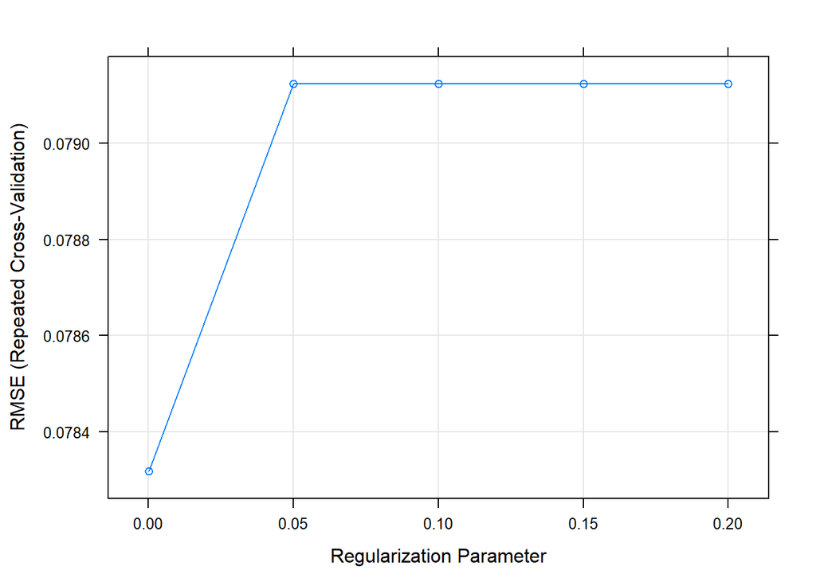

```r
par(mfrow=c(1,2))
a <- plot(lasso_clus2)
a
```

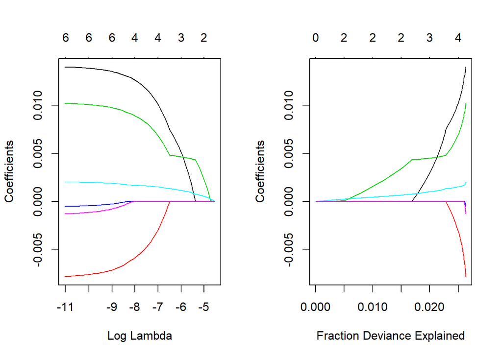

```r
b <- plot(lasso_clus2$finalModel,xvar="lambda", label=T)
c <- plot(lasso_clus2$finalModel,xvar="dev",label=T)
```

*Apply Lasso Regression Model to Test Set and Evaluate via RMSE, MSE, and MAE*

```r
test_lasso_slope_clus2 <- predict(lasso_clus2 , newdata =test_set_clus2)

#RMSE
lasso_rmse_clus2 <- rmse(test_set_clus2$ALSFRS_Slope, test_lasso_slope_clus2)
lasso_rmse_clus2
```

```
## [1] 0.06963155
```

```r
#MSE
lasso_mse_clus2 <- mse(test_set_clus2$ALSFRS_Slope, test_gbm_slope_clus2)
lasso_mse_clus2
```

```
## [1] 0.004854784
```

```r
#MAE
lasso_mae_clus2 <- mean(abs(test_gbm_slope_clus2-test_set_clus2$ALSFRS_Slope))
lasso_mae_clus1
```

```
## [1] 0.03439422
```

#### **V. Elastic Net**

The last algorithm we trained was Elastic Net, which is also from the glmnet library. By definition, elastic net is a hybrid regularization method of both ridge and lasso regression. Specifically, it penalizes both coefficients and square of coefficients of variables.

**Cluster 1**

*Train Elastic Net Model*

```r
#for reproducibility
set.seed(1234)
#use this setting for trainControl
custom <- trainControl(method = "repeatedcv", number=10, repeats = 5, verboseIter = F)
#train elastic net model
en_clus1 <- train(ALSFRS_Slope ~ .-subject_id, training_set_clus1, method="glmnet", tuneGrid=expand.grid(alpha=seq(0,1,length=10), lambda=seq(0.0001, 0.001, length=5)), trControl=custom)
en_clus1
```

```
## glmnet
##
## 67 samples
##  7 predictor
##
## No pre-processing
## Resampling: Cross-Validated (10 fold, repeated 5 times)
## Summary of sample sizes: 60, 60, 61, 60, 62, 59, ...
## Resampling results across tuning parameters:
##
##   alpha      lambda    RMSE        Rsquared   MAE
##   0.0000000  0.000100  0.03801981  0.2522002  0.03023951
##   0.0000000  0.000325  0.03801981  0.2522002  0.03023951
##   0.0000000  0.000550  0.03801981  0.2522002  0.03023951
##   0.0000000  0.000775  0.03801981  0.2522002  0.03023951
##   0.0000000  0.001000  0.03802165  0.2521752  0.03024037
##   0.1111111  0.000100  0.03830880  0.2529384  0.03044861
##   0.1111111  0.000325  0.03825145  0.2526480  0.03041571
##   0.1111111  0.000550  0.03819909  0.2524118  0.03038213
##   0.1111111  0.000775  0.03815222  0.2521686  0.03034883
##   0.1111111  0.001000  0.03811097  0.2519003  0.03031680
##   0.2222222  0.000100  0.03831016  0.2528207  0.03045115
##   0.2222222  0.000325  0.03825384  0.2523181  0.03042104
##   0.2222222  0.000550  0.03820281  0.2518539  0.03038841
##   0.2222222  0.000775  0.03815968  0.2512935  0.03035674
##   0.2222222  0.001000  0.03812318  0.2506281  0.03032739
##   0.3333333  0.000100  0.03831106  0.2526934  0.03045338
##   0.3333333  0.000325  0.03825524  0.2520008  0.03042505
##   0.3333333  0.000550  0.03820760  0.2512174  0.03039473
##   0.3333333  0.000775  0.03816870  0.2501666  0.03036386
##   0.3333333  0.001000  0.03813695  0.2489785  0.03033674
##   0.4444444  0.000100  0.03831210  0.2525841  0.03045565
##   0.4444444  0.000325  0.03825733  0.2516764  0.03042919
##   0.4444444  0.000550  0.03821345  0.2504394  0.03040077
##   0.4444444  0.000775  0.03817891  0.2488811  0.03036970
##   0.4444444  0.001000  0.03815459  0.2470969  0.03034683
##   0.5555556  0.000100  0.03831320  0.2524614  0.03045806
##   0.5555556  0.000325  0.03825959  0.2513077  0.03043335
##   0.5555556  0.000550  0.03821937  0.2495829  0.03040562
##   0.5555556  0.000775  0.03819117  0.2474206  0.03037725
```

[output cut: 9 more lines]

```
##   0.7777778  0.000775  0.03821886  0.2446637  0.03038890
##   0.7777778  0.001000  0.03818650  0.2438960  0.03034209
##   0.8888889  0.000100  0.03831473  0.2521741  0.03046311
##   0.8888889  0.000325  0.03826848  0.2499259  0.03044497
##   0.8888889  0.000550  0.03824251  0.2466701  0.03041787
##   0.8888889  0.000775  0.03822394  0.2437485  0.03038345
##   0.8888889  0.001000  0.03818898  0.2438101  0.03032786
##   1.0000000  0.000100  0.03831512  0.2520847  0.03046458
##   1.0000000  0.000325  0.03827172  0.2493945  0.03044823
##   1.0000000  0.000550  0.03825177  0.2456826  0.03042073
##   1.0000000  0.000775  0.03822583  0.2435167  0.03037490
##   1.0000000  0.001000  0.03819110  0.2437581  0.03031037
##
## RMSE was used to select the optimal model using the smallest value.
## The final values used for the model were alpha = 0 and lambda = 0.000775.
```

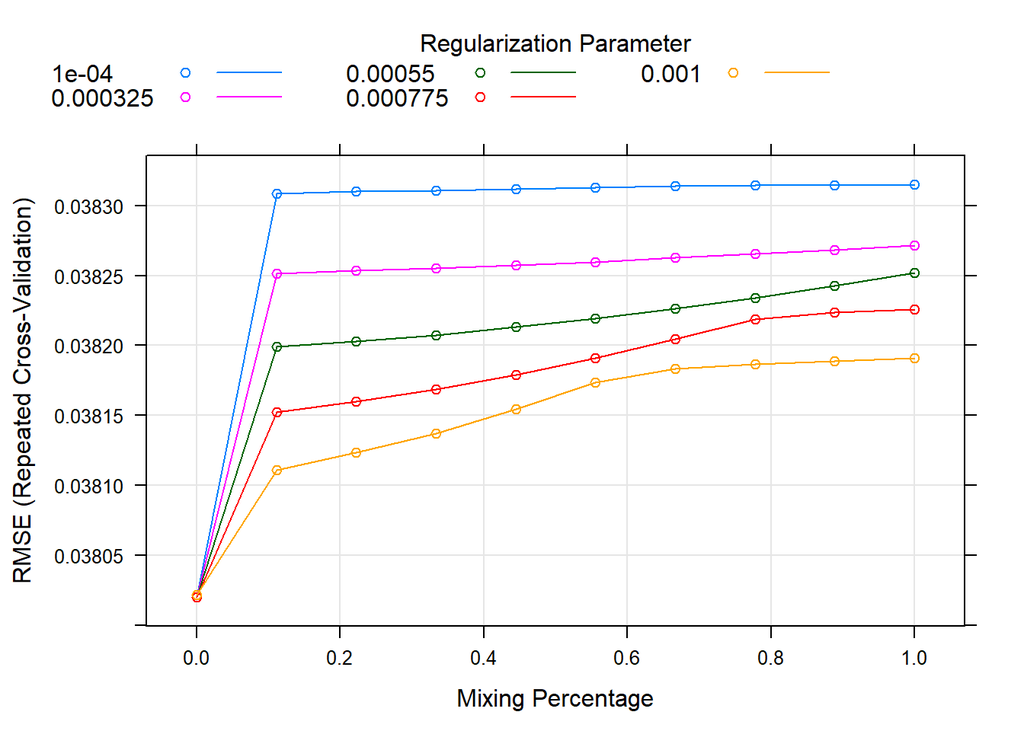

```r
par(mfrow=c(1,2))
a <- plot(en_clus1)
a
```

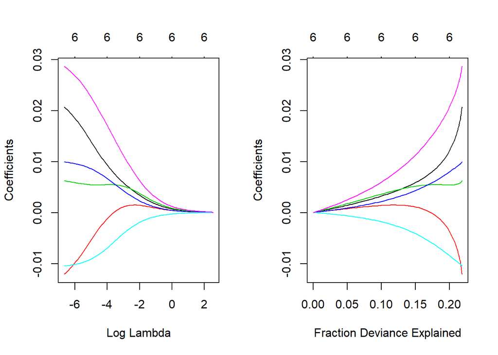

```r
b <- plot(en_clus1$finalModel,xvar="lambda",label=T)
c <- plot(en_clus1$finalModel,xvar="dev",label=T)
```

*Apply GLMNET Elastic Net Model to Test Set and Evaluate via RMSE, MSE, and MAE*

```r
#apply model to test set
test_en_slope_clus1 <- predict(en_clus1 , newdata =test_set_clus1)

#RMSE
en_rmse_clus1 <- rmse(test_set_clus1$ALSFRS_Slope, test_en_slope_clus1)
en_rmse_clus1
```

```
## [1] 0.04412381
```

```r
#MSE
en_mse_clus1 <- mse(test_set_clus1$ALSFRS_Slope, test_en_slope_clus1)
en_mse_clus1
```

```
## [1] 0.001946911
```

```r
#MAE
en_mae_clus1 <- mean(abs(test_en_slope_clus1-test_set_clus1$ALSFRS_Slope))
en_mae_clus1
```

```
## [1] 0.03412279
```

**Cluster 2**

*Create GLMNET Model: Elastic Net*

```r
#for reproducibility
set.seed(1234)
#train model using the trainControl hyperparameter in the previous chunk
en_clus2 <- train(ALSFRS_Slope ~ .-subject_id, training_set_clus2, method="glmnet", tuneGrid=expand.grid(alpha=seq(0,1,length=10), lambda=seq(0.0001, 0.001, length=5)), trControl=custom)
en_clus2
```

```
## glmnet
##
## 1797 samples
##    7 predictor
##
## No pre-processing
## Resampling: Cross-Validated (10 fold, repeated 5 times)
## Summary of sample sizes: 1617, 1618, 1618, 1617, 1618, 1616, ...
## Resampling results across tuning parameters:
##
##   alpha      lambda    RMSE        Rsquared    MAE
##   0.0000000  0.000100  0.07831202  0.03041615  0.04101432
##   0.0000000  0.000325  0.07831202  0.03041615  0.04101432
##   0.0000000  0.000550  0.07831202  0.03041615  0.04101432
##   0.0000000  0.000775  0.07831202  0.03041615  0.04101432
##   0.0000000  0.001000  0.07831203  0.03041625  0.04101434
##   0.1111111  0.000100  0.07832270  0.03037843  0.04103942
##   0.1111111  0.000325  0.07831828  0.03038084  0.04102474
##   0.1111111  0.000550  0.07831426  0.03039085  0.04101134
##   0.1111111  0.000775  0.07830984  0.03041530  0.04099754
##   0.1111111  0.001000  0.07830516  0.03044842  0.04098354
##   0.2222222  0.000100  0.07832197  0.03037300  0.04103584
##   0.2222222  0.000325  0.07831607  0.03037794  0.04101445
##   0.2222222  0.000550  0.07830957  0.03041114  0.04099261
##   0.2222222  0.000775  0.07830140  0.03050042  0.04096921
##   0.2222222  0.001000  0.07829227  0.03063257  0.04094592
##   0.3333333  0.000100  0.07832129  0.03036665  0.04103235
##   0.3333333  0.000325  0.07831358  0.03038051  0.04100355
##   0.3333333  0.000550  0.07830314  0.03048291  0.04097181
##   0.3333333  0.000775  0.07829078  0.03066361  0.04093965
##   0.3333333  0.001000  0.07827956  0.03084219  0.04090894
##   0.4444444  0.000100  0.07832058  0.03036318  0.04102899
##   0.4444444  0.000325  0.07831050  0.03039826  0.04099194
##   0.4444444  0.000550  0.07829563  0.03059341  0.04095059
##   0.4444444  0.000775  0.07828095  0.03082277  0.04091096
##   0.4444444  0.001000  0.07826948  0.03099580  0.04087524
##   0.5555556  0.000100  0.07831985  0.03036231  0.04102575
##   0.5555556  0.000325  0.07830662  0.03044162  0.04097942
##   0.5555556  0.000550  0.07828814  0.03071280  0.04092953
##   0.5555556  0.000775  0.07827253  0.03095315  0.04088433
```

[output cut: 10 more lines]

```
##   0.7777778  0.001000  0.07826875  0.03078471  0.04079670
##   0.8888889  0.000100  0.07831778  0.03035793  0.04101599
##   0.8888889  0.000325  0.07829317  0.03063835  0.04094143
##   0.8888889  0.000550  0.07827055  0.03097489  0.04087235
##   0.8888889  0.000775  0.07826686  0.03089183  0.04081823
##   0.8888889  0.001000  0.07827358  0.03061566  0.04077611
##   1.0000000  0.000100  0.07831710  0.03035711  0.04101272
##   1.0000000  0.000325  0.07828880  0.03070836  0.04092899
##   1.0000000  0.000550  0.07826798  0.03098347  0.04085555
##   1.0000000  0.000775  0.07826934  0.03078222  0.04080034
##   1.0000000  0.001000  0.07827991  0.03041421  0.04075781
##
## RMSE was used to select the optimal model using the smallest value.
## The final values used for the model were alpha = 0.5555556 and lambda
##  = 0.001.
```

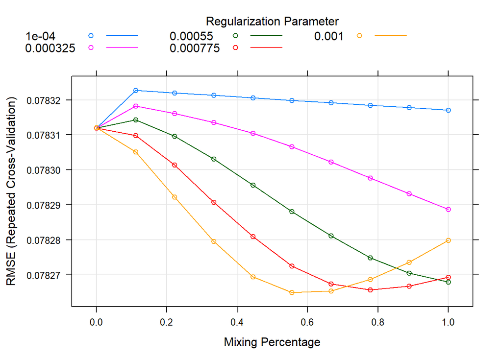

```r
par(mfrow=c(1,2))
a <- plot(en_clus2)
a
```

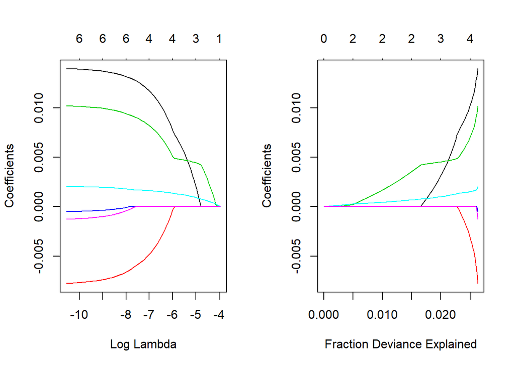

```r
b <- plot(en_clus2$finalModel,xvar="lambda",label=T)
c <- plot(en_clus2$finalModel,xvar="dev",label=T)
```

*Apply Elastic Net Model to Test Set and Evaluate via RMSE, MSE, MAE*

```r
#apply on test set
test_en_slope_clus2 <- predict(en_clus2, newdata =test_set_clus2)

#RMSE
en_rmse_clus2 <- rmse(test_set_clus2$ALSFRS_Slope, test_en_slope_clus2)
en_rmse_clus2
```

```
## [1] 0.06971422
```

```r
#MSE
en_mse_clus2 <- mse(test_set_clus2$ALSFRS_Slope, test_en_slope_clus2)
en_mse_clus2
```

```
## [1] 0.004860072
```

```r
#MAE
en_mae_clus2 <- mean(abs(test_en_slope_clus2-test_set_clus2$ALSFRS_Slope))
en_mae_clus2
```

```
## [1] 0.04059466
```

#### **VI. Comparing the Models: RMSE, MSE, and MAE**

**A. Cluster 1**

```r
#create a data frame that combines all the RMSE, MSE, and MAE for all of the algorithms we trained and tested for cluster 1
accuracy_cluster1 <- data.frame(Method = c("Baseline","Random_Forests", "GBM", "Lasso", "Elastic_Net"),RMSE=c(RMSE_baseline_clus1, rf_rmse_clus1, gbm_rmse_clus1, lasso_rmse_clus1, en_rmse_clus1),MSE=c(MSE_baseline_clus1,rf_mse_clus1,gbm_mse_clus1,lasso_mse_clus1,en_mse_clus1), MAE=c(MAE_baseline_clus1,rf_mae_clus1,gbm_mae_clus1,lasso_mae_clus1,en_mae_clus1))

accuracy_cluster1
```

```
##           Method       RMSE         MSE        MAE
## 1       Baseline 0.04341245 0.001884641 0.03463923
## 2 Random_Forests 0.04180745 0.001747863 0.03301306
## 3            GBM 0.04207325 0.001770158 0.03342604
## 4          Lasso 0.04443033 0.001770158 0.03439422
## 5    Elastic_Net 0.04412381 0.001946911 0.03412279
```

**B. Cluster 2**

```r
#create a data frame that combines all the RMSE, MSE, and MAE for all of the algorithms we trained and tested for cluster 2
accuracy_cluster2 <- data.frame(Method = c("Baseline","Random_Forests", "GBM", "Lasso", "Elastic_Net"),RMSE=c(RMSE_baseline_clus2, rf_rmse_clus2, gbm_rmse_clus2, lasso_rmse_clus2, en_rmse_clus2),MSE=c(MSE_baseline_clus2,rf_mse_clus2,gbm_mse_clus2,lasso_mse_clus2,en_mse_clus2), MAE=c(MAE_baseline_clus2,rf_mae_clus2,gbm_mae_clus2,lasso_mae_clus2,en_mae_clus2))

accuracy_cluster2
```

```
##           Method       RMSE         MSE        MAE
## 1       Baseline 0.07185784 0.005163550 0.04276809
## 2 Random_Forests 0.07056459 0.004979362 0.04103804
## 3            GBM 0.06967628 0.004854784 0.04104213
## 4          Lasso 0.06963155 0.004854784 0.04104213
## 5    Elastic_Net 0.06971422 0.004860072 0.04059466
```

#### **VII. Determine Goodness of Fit of Models via Actual vs. Predicted Plots**

**A. Cluster 1**

```r
#create a data frame
predictions_clus1 <- data.frame(actual = test_set_clus1$ALSFRS_Slope,
                              Baseline = baseline_mean_clus1,
                              Random_Forests = test_RF_slope_clus1,
                              GBM = test_gbm_slope_clus1,
                              Lasso = test_gbm_slope_clus1,
                              Elastic_Net = test_en_slope_clus1)
head(predictions_clus1)
```

```
##        actual    Baseline Random_Forests         GBM       Lasso
## 1 -0.01111111 -0.02124798   -0.007750911 -0.02125971 -0.02125971
## 2 -0.09523810 -0.02124798    0.005520703 -0.01680329 -0.01680329
## 3  0.00000000 -0.02124798   -0.032473530 -0.03242842 -0.03242842
## 4  0.01388889 -0.02124798   -0.057345578 -0.02182034 -0.02182034
## 5 -0.08333333 -0.02124798   -0.016793661 -0.01224816 -0.01224816
## 6 -0.03571429 -0.02124798   -0.036506897 -0.02615901 -0.02615901
##    Elastic_Net
## 1 -0.019377983
## 2 -0.011032617
## 3 -0.041178721
## 4 -0.031312964
## 5 -0.007804195
## 6 -0.056836125
```

```r
all_predictions_clus1 <- predictions_clus1 %>% gather(key = model,value = predictions,2:6)

rf <- all_predictions_clus1 %>% filter(model=="Random_Forests")
gbm <- all_predictions_clus1 %>% filter(model=="GBM")
lasso <- all_predictions_clus1 %>% filter(model=="Lasso")
elastic_net <- all_predictions_clus1 %>% filter(model=="Elastic_Net")
```

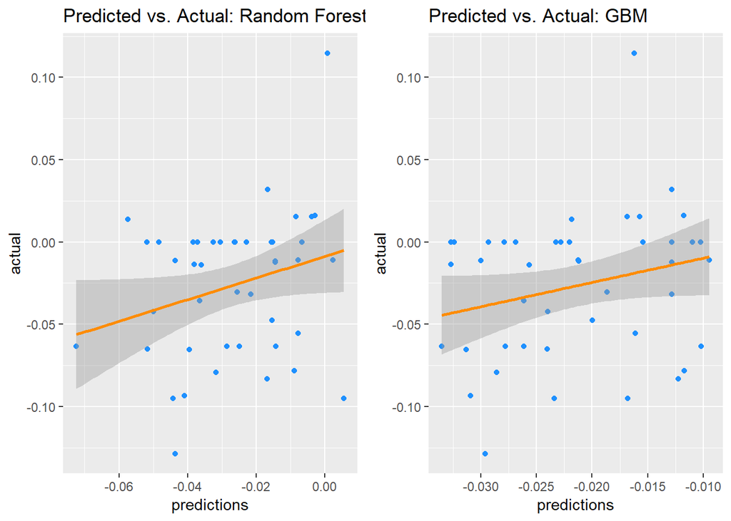

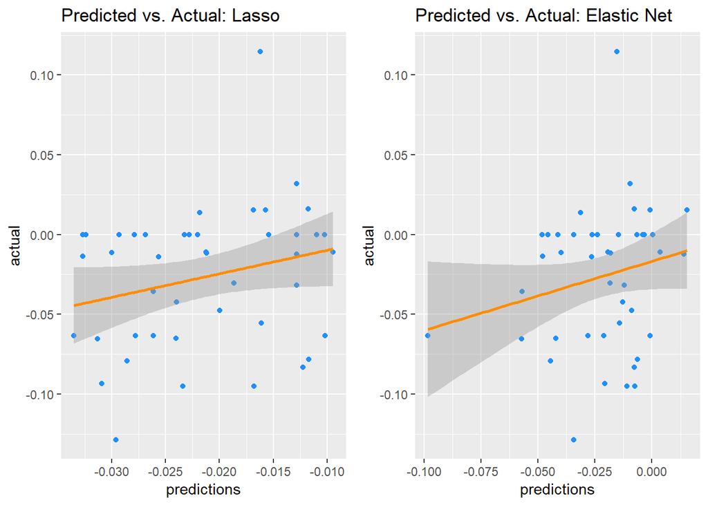

```r
#random forests
rf_plot_clus1<- ggplot(data = rf,aes(x = predictions, y = actual)) +
  geom_point(colour = "dodgerblue") +
  geom_smooth(method = "lm", colour = "darkorange")+
  ggtitle("Predicted vs. Actual: Random Forests")
#GBM
gbm_plot_clus1 <- ggplot(data = gbm, aes(x = predictions, y = actual)) +
  geom_point(colour = "dodgerblue") +
  geom_smooth(method = "lm", colour = "darkorange") +
  ggtitle("Predicted vs. Actual: GBM")
#Lasso
lasso_plot_clus1 <- ggplot(data = lasso,aes(x = predictions, y = actual)) +
  geom_point(colour = "dodgerblue") +
  geom_smooth(method = "lm", colour = "darkorange")+
  ggtitle("Predicted vs. Actual: Lasso")
#elastic net
elastic_net_plot_clus1<- ggplot(data = elastic_net,aes(x = predictions, y = actual)) +
  geom_point(colour = "dodgerblue") +
  geom_smooth(method = "lm", colour = "darkorange") +
  ggtitle("Predicted vs. Actual: Elastic Net")
```

**B. Cluster 2**

```r
predictions_clus2 <-  data.frame(actual = test_set_clus2$ALSFRS_Slope,
                              Baseline = baseline_mean_clus2,
                              Random_Forests = test_RF_slope_clus2,
                              GBM = test_gbm_slope_clus2,
                              Lasso = test_gbm_slope_clus2,
                              Elastic_Net = test_en_slope_clus2)
head(predictions_clus2)
```

```
##        actual    Baseline Random_Forests         GBM       Lasso
## 1  0.04166667 -0.02374928   -0.027633038 -0.02807113 -0.02807113
## 2 -0.08988764 -0.02374928   -0.030405277 -0.02834556 -0.02834556
## 3  0.00000000 -0.02374928   -0.008308538 -0.01239962 -0.01239962
## 4  0.01587302 -0.02374928   -0.010265512 -0.01312688 -0.01312688
## 5  0.00000000 -0.02374928   -0.003600648 -0.01262550 -0.01262550
## 6 -0.02985075 -0.02374928   -0.029038079 -0.02914031 -0.02914031
##   Elastic_Net
## 1 -0.01713528
## 2 -0.03039923
## 3 -0.02280848
## 4 -0.02102095
## 5 -0.01131767
## 6 -0.02260535
```

```r
all_predictions_clus2 <- predictions_clus2 %>% gather(key = model,value = predictions,2:6)

rf <- all_predictions_clus2 %>% filter(model=="Random_Forests")
gbm <- all_predictions_clus2 %>% filter(model=="GBM")
lasso <- all_predictions_clus2 %>% filter(model=="Lasso")
elastic_net <- all_predictions_clus2 %>% filter(model=="Elastic_Net")
```

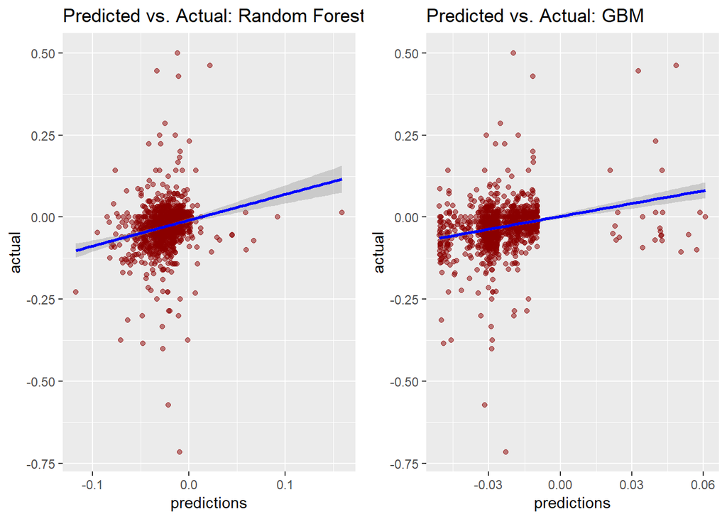

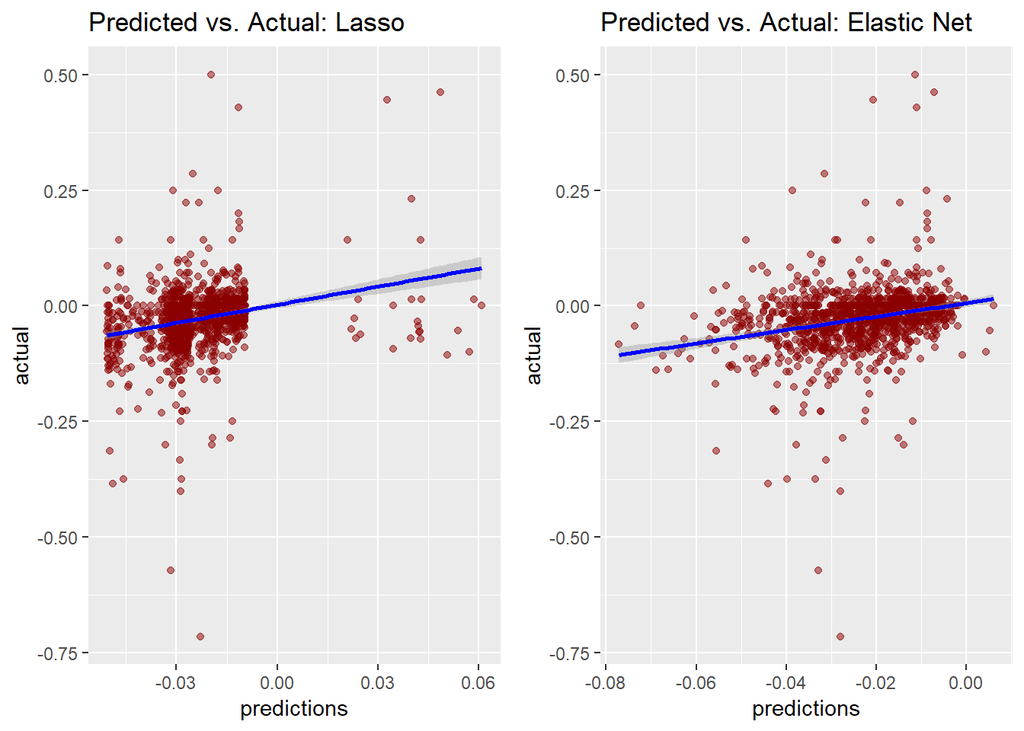

```r
rf_plot_clus2<- ggplot(data = rf,aes(x = predictions, y = actual)) +
  geom_point(colour = "darkred", alpha=0.5) +
  geom_smooth(method = "lm", colour = "blue") +
  ggtitle("Predicted vs. Actual: Random Forests")

gbm_plot_clus2 <- ggplot(data = gbm,aes(x = predictions, y = actual)) +
  geom_point(colour = "darkred", alpha=0.5) +
  geom_smooth(method = "lm", colour = "blue") +
  ggtitle("Predicted vs. Actual: GBM")

lasso_plot_clus2<- ggplot(data = lasso,aes(x = predictions, y = actual)) +
  geom_point(colour = "darkred", alpha=0.5) +
  geom_smooth(method = "lm", colour = "blue") +
  ggtitle("Predicted vs. Actual: Lasso")

elastic_net_plot_clus2<- ggplot(data = elastic_net,aes(x = predictions, y = actual)) +
  geom_point(colour = "darkred", alpha=0.5) +
  geom_smooth(method = "lm", colour = "blue")  +
  ggtitle("Predicted vs. Actual: Elastic Net")
```

#### **VIII. Conclusion/Limitations/Future Work**

*Conclusion*

Although ALS has been known in scientific literature for over 150 years, the disease process, management, and treatment have not been well-understood mostly due to its heterogenity in patients. Thus, in 2012 and 2015, the the DREAM-Phil Bowen ALS Prediction Prize4Life Challenge and DREAM ALS Stratification Prize4Life Challenge were created. Specifically, it invited participants from all over the world to devise a stratification algorithm that will cluster the different types of ALS patients into groups based on their common features. In addtion, the participants were challenged to predict the disease progression in 3-12 months via ALSFRS slope and/or survival rate for 12, 18, and 24 months.

As group, we chose to focus on the first sub-challenge of predicting the 3-12 month ALSFRS Slope using the Pooled Resource Open-Access ALS Clinical Trials (PRO-ACT). Out of more than 20,000 patients and hundreds of features associated with them (e.g. laboratory works, demographics, and ALS history), we were able to condense the dataset in a manageable number of 3140 patient and 40 variables.

Using Kmeans algorithm, we were able to cluster the patients into 2 groups. Patients in cluster 2 have seem to be in a more normal functional state because they have higher 0-90 Days ALSFRS Slope, Weight, Forced Vital Capacity (FVC), and Creatinine levels.

One of the biggest challenge for this project is that only 6 variables are allowed for any of the predictions as stated in the original rules of the ALS Dream Challenge. To solve this, we used Recursive Feature Elimination (RFE) with Random Forests. For the first cluster, the top 6 variables were: Q3_Swallowing, Q2_Salivation, Site_of_Onset, Subject_Liters_Trial_1, Q7_Turning_in_Bed, Study_Arm. For the second cluster, the top 6 variables were Site_of_Onset, Q2_Salivation, Q3_Swallowing, Subject_Liters_Trial_1, ALSFRS_Total, Q5a_Cutting_without_Gastrostomy.

*Limitations and Future Work*

The biggest limitation of this project is that we are not able to compare the relative predictive accuracy of our models to the actual modesl of the participants of the ALS dream challenge because we do not have access to the leaderboards. In the past actual contests, the predictive accuracy of the models of the participants were assessed via the check_submission on the IBM Server. Based on that, they were able to make revisions to their algorithms up to until the challenge deadline.

For future directions and further understanding of ALS, we want to work on the the ALS Dream Subchallenge 2 which predicts the 12, 18, and 24 month survival of patients. In addition, we want to use the ALS registries dataset to analyze and perform our predictions.

#### **XI. References**

[1] https://theanalyticalminds.blogspot.com/2015/04/part-4a-modelling-predicting-amount-of.html?m=1&fbclid=IwAR3fVcUHmT_-IKmLA1PqfxvUX9HqvfVUZfp7Sblhnswj2TeDKCB1sda3_yE

[2] https://consumer.healthday.com/cognitive-health-information-26/lou-gehrig-s-disease-als-news-1/blood-test-might-help-predict-survival-with-lou-gehrig-s-disease-689969.html

[3] https://www.synapse.org/#!Synapse:syn2873386/wiki/391426